# Vendor Masterfile EDA

## by Amr Muhammad

## Investigation Overview

This is an investigation of the completeness and authenticity of vendor records and related transactions as well as the prevailing procurement practices, aimed at highlighting irregularities in the underlying datasets to guide sampling and further analysis of these irregularities.

## Dataset Overview

There are 5 independent datasets as follows:

- Vendor master file: Details of each vendor (ID, name, contact person, tax number, phone, address, etc...) and details about record creation and modification (creation/modification user ID and date)
- Access rights: details (ID and department) of authorized personnel to create/modify vendor records
- Active employees: details of active employees (name, ID, hiring date, department, etc...)
- Terminated employees: details of terminated employees (name, ID, termination date, department, etc...)
- Purchase Order (PO): details of POs for a given period (status, date, amount, item description, value, vendor, etc...)

## Missing vendor details

It is customary that some details go missing due to input errors; However, nature of missing details signifies its importance. All records missing Tin numbers (taxpayer identification number) needs to be thoroughly investigated as these could be fictitious vendors, also in some regions companies get charged with taxes due on vendors they deal with incase the vendor commit tax evasion

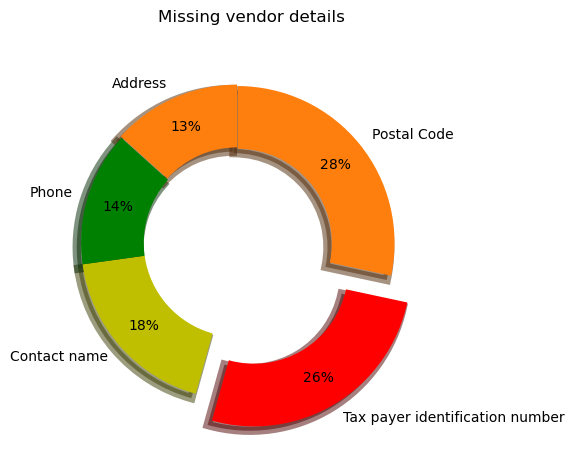

```python
# missing vendor details

plt.subplots(figsize=(15, 5), dpi = 100)

missing_details_count = vmf_df.isna().sum()

missing_details_count = missing_details_count[missing_details_count > 0].sort_values(ascending=False)

labels= ['Postal Code', 'Tax payer identification number', 'Contact name', 'Phone', 'Address']

colors = ['tab:orange', 'r', 'y', 'g', 'tab:orange']

explode = [0, 0.2, 0, 0, 0.01]

plt.pie(missing_details_count, labels= labels, colors = colors, explode = explode, startangle= 90,
        counterclock= False, wedgeprops={'width' : 0.4, 'linewidth': 6},
        autopct = lambda p: '{:.0f}%'.format(round(p)) if p > 0 else '', pctdistance = 0.8, shadow = True)

plt.title('Missing vendor details', y = 1.1)
plt.axis('square');
```

## Vendors having highest similarities across all records

Analysing similarities across all vendor details provides some guidance on sampling and document inspection later on. This plot summarize the results of this analysis that was based calculating similarities between vendor names to spot on exact and fuzzy duplicates then calculating similarities across rest of vendor details (address, phone, etc...). We can note that Initial supplier registration does not follow a systematic usage of naming conventions; also, the ERP system (assuming that there is one) does not detect duplicated vendor details.

Such practice may lead to duplicate payments and fraudulent transactions.

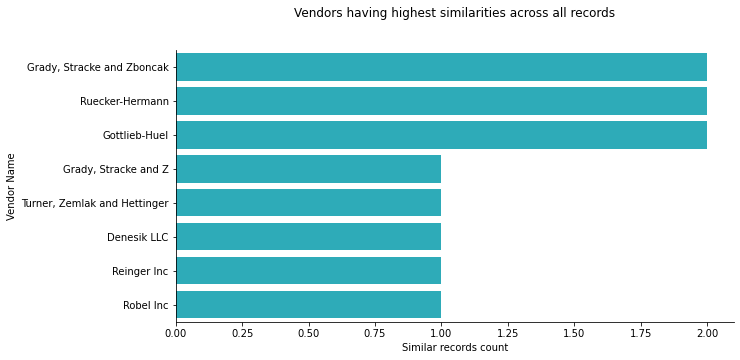

```python
# vendor names exact and fuzzy matches with similarity scores

# finding exact and fuzzy matches between vendor names and calculating similarity scores to identify possible duplicates
# matching is based on specified n_gram and number of desired matches 'n_matches'.
# n_gram and n_matches default values are 3 and 10 respectively which mostly yield best results
# results are not filtered but are sorted in a descending order for convenience.

def similar(df, col1, col2):
    '''calculate similarities of returned results from tfidf matcher
    to facilitate filtering results'''
    return round(SequenceMatcher(None, df[col1], df[col2]).ratio(),2)

vendor_name = vmf_df.name.tolist()

match_name = vmf_df.name.tolist()

vn_name_match_df=tm.matcher(vendor_name , match_name, ngram_length= 3, k_matches= 10)

vn_name_match_df=pd.merge(vn_name_match_df,vmf_df[['id']], left_index=True,right_index=True,how='left')

vn_name_match_df.drop_duplicates(subset='Original Name', inplace=True)

vn_name_match_df.drop(columns=['Match Confidence','Lookup 1'], inplace=True)

vn_name_match_df.reset_index(drop=True, inplace=True)

vn_name_match_df=vn_name_match_df.melt(id_vars=["Original Name", 'id'],ignore_index=False)

vn_name_match_df.drop(columns=['variable'], inplace=True)

vn_name_match_df.reset_index(drop=True, inplace=True)

vn_name_match_df['similarity']=vn_name_match_df.apply(similar,args=('Original Name', 'value'),axis=1)

vn_name_match_df.index=vn_name_match_df.value

vmf_df.index=vmf_df.name

# collecting vendor details for matched vendors
vn_name_match_df=pd.merge(vn_name_match_df,vmf_df[['id','vendor_status']], left_index=True,right_index=True,how='left')

vn_name_match_df.reset_index(drop=True, inplace=True)

vmf_df.reset_index(drop=True, inplace=True)

# remove duplicate records
temp_df=vn_name_match_df.groupby(['id_x','Original Name', 'id_y', 'value', 'similarity', 'vendor_status'])['value'].count().to_frame()

vn_name_match_df= temp_df.index.to_frame()

vn_name_match_df.reset_index(drop=True, inplace=True)

# remove exact id matches
vn_name_match_df=vn_name_match_df[vn_name_match_df.id_x != vn_name_match_df.id_y]

vn_name_match_df[['id_x','id_y']] = vn_name_match_df[['id_x','id_y']].astype(str)

# removing reverse duplicate matches to eliminate data redundancy,
# i.e: match result of x,y and y,x basically refer to same records
# first we join and sort both vendor ids to create a unique value for each result
# then drop duplicate joined ids
vn_name_match_df['reverse_duplicates'] = vn_name_match_df.apply(lambda row: ''.join(sorted([row.id_x, row.id_y])), axis=1)

vn_name_match_df.drop_duplicates(subset='reverse_duplicates', inplace=True)

vn_name_match_df.drop(columns='reverse_duplicates', inplace=True)

vn_name_match_df.reset_index(drop=True, inplace=True)

# collecting all match vendor details and sorting data for better view and comparison
vn_name_match_df[['id_x','id_y']] = vn_name_match_df[['id_x','id_y']].astype(float)

vn_name_match_df.rename(columns={'id_x':'id','Original Name':'name'}, inplace=True)

vn_name_match_df=pd.merge(vn_name_match_df,vmf_df[['id', 'phone', 'postal_code', 'address',
                                                   'taxpayer_identification_number_tin']], on='id', how='left')

vn_name_match_df.rename(columns={'id':'vendor_id','name':'vendor_name','phone':'vendor_phone',
                                 'postal_code':'vendor_postal_code', 'address':'vendor_address',
                                 'taxpayer_identification_number_tin':'vendor_tin'}, inplace=True)

vn_name_match_df.rename(columns={'id_y':'id','value':'name'}, inplace=True)

vn_name_match_df=pd.merge(vn_name_match_df,vmf_df[['id', 'phone', 'postal_code', 'address',
                                                   'taxpayer_identification_number_tin']], on='id', how='left')

vn_name_match_df.rename(columns={'id':'match_vendor_id', 'name':'match_vendor_name', 'phone':'match_vendor_phone',
                                 'postal_code':'match_vendor_postal_code', 'address':'match_vendor_address',
                                 'taxpayer_identification_number_tin':'match_vendor_tin'}, inplace=True)

result_columns=vn_name_match_df.columns.tolist()

columns_sort=result_columns[:2]+result_columns[3:4]+result_columns[2:3]+result_columns[4:6]+result_columns[6:7] \
+result_columns[10:11]+result_columns[7:8]+result_columns[11:12]+result_columns[8:9]+result_columns[12:13] \
+result_columns[9:10]+result_columns[13:]

vn_name_match_df=vn_name_match_df[columns_sort].sort_values(by='similarity', ascending=False)

r1 = vn_name_match_df.copy()

# calcualting similarites across all details (phone, address, posta, tin, etc...) of filtered records

def similar_with_nan(df, col1, col2):
    '''calculate similarities between two dataframe columns while ignoring nan values'''
    if not df[[col1,col2]].isnull().any():
        return round(SequenceMatcher(None, df[col1], df[col2]).ratio(),2)
    else:
        return 0

temp_vn_df = r1.copy()

temp_vn_df = temp_vn_df[temp_vn_df.similarity >= .8]

for i, e in zip(*[iter(temp_vn_df.columns[6:])] * 2):
    result = temp_vn_df.apply(similar_with_nan,args=(i,e),axis=1)
    temp_vn_df[i] = result
    temp_vn_df.drop(columns=e,inplace=True)

temp_vn_df['total_similarity_score'] = temp_vn_df['similarity'] + temp_vn_df.iloc[:,-5:-1].sum(axis=1)

r2 = temp_vn_df.copy().sort_values(by='total_similarity_score', ascending=False)

# summary of similarity across all vendor details,
# only exact name duplicates and highest total similarities across all details are considered,
# score of 2 and above provided best result filter. I wanna highlight fuzzy duplicates that are
# a highly possible match, as exact matches are already clear

r3 = r2[r2.total_similarity_score >= 2]

r3 = r3[r3.columns[0:4]]

r3.reset_index(drop=True, inplace=True)

# PLotting number of records with highest similarity across all vendor details

plt.subplots(figsize=(10, 5))

color = sb.color_palette()[9]

order = r3.vendor_name.value_counts().index

sb.countplot(y = r3.vendor_name, color = color, order = order)

plt.title('Vendors having highest similarities across all records', y = 1.1)

plt.ylabel('Vendor Name')

plt.xlabel('Similar records count')

plt.gca().spines["top"].set_alpha(0.0); plt.gca().spines["right"].set_alpha(0.0)
```

## Unauthorized modifications of vendor Master file records

Restricting access and edits to vendor master file is a key control, we've analysed all edits to the file against the approved access rights and it’s clear that access rights are not properly managed. A total of 42 records were modified by unauthorized personnel of which 62% are active employees; Although access rights are already predefined, it might not be enforced or users can bypass.

User account management is also experiencing a significant control weakness as 3 records were edited by personnel after their termination data, this implies that they either still have access to company's network or their accounts were not deactivated after their termination and are used by internal users.

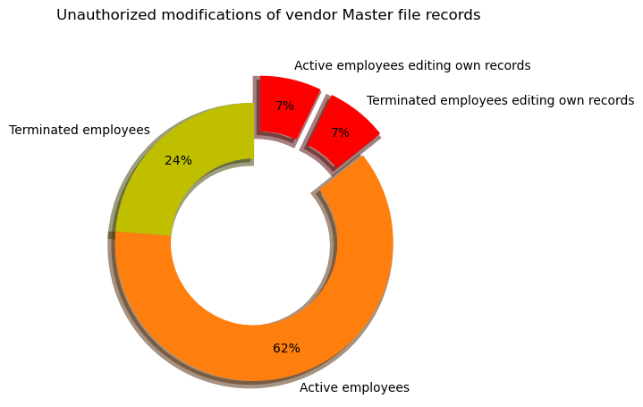

```python
# access rights review
# identify any unauthorized record manipulation
# by comparing edit history to approved access rights and employee records

# building the dataframe of unauthorized access rights either modification of creation
creation_temp_df = vmf_df[~vmf_df.creation_user_id.isin(access_rights_df.creation_user_id)]

modification_temp_df = vmf_df[~vmf_df.modification_user_id.isin(access_rights_df.modification_user_id)]

access_rights_review_df = creation_temp_df.append(modification_temp_df)

access_rights_review_df.reset_index(drop=True, inplace=True)

employees_df['employee_status'] = 'Active'

terminated_employees_df['employee_status'] = 'Terminated'

# adjusting column length to exact match in both dataframes
fltrt_term_df=terminated_employees_df[employees_df.columns]

temp_employee_df=employees_df.append(fltrt_term_df)

# collecting all active/terminated employee details and sorting data for better view and comparison
access_rights_review_df.index=access_rights_review_df.creation_user_id

temp_employee_df.index=temp_employee_df.employee_id

access_rights_review_df=pd.merge(access_rights_review_df,temp_employee_df[['departement', 'employee_status', 'employee_name']],
                                 left_index=True, right_index=True, how='left')

access_rights_review_df.rename(columns={'departement':'creation_user_departement', 'employee_status':'creation_user_status',
                                        'employee_name':'creation_user_name'}, inplace=True)

access_rights_review_df.index=access_rights_review_df.modification_user_id

access_rights_review_df=pd.merge(access_rights_review_df,temp_employee_df[['departement', 'employee_status', 'employee_name']],
                                 left_index=True, right_index=True, how='left')

access_rights_review_df.rename(columns={'departement':'modification_user_departement',
                                        'employee_status':'modification_user_status', 'employee_name':'modification_user_name',
                                        'id':'vendor_id', 'name':'vendor_name'}, inplace=True)

# mapping termination date to terminated employees
for i in access_rights_review_df.creation_user_id.unique():
    term_date_dict=terminated_employees_df.set_index('employee_id').to_dict()['termination_date']

    if i in terminated_employees_df.employee_id.values:
        access_rights_review_df['termination_date']=access_rights_review_df.creation_user_id.map(term_date_dict)
    else:
        access_rights_review_df['termination_date']=access_rights_review_df.modification_user_id.map(term_date_dict)

access_rights_review_df.drop_duplicates(subset = 'vendor_id', inplace =True)

access_rights_review_df.reset_index(drop=True, inplace=True)

temp_employee_df.reset_index(drop=True, inplace=True)

result_columns=access_rights_review_df.columns.tolist()

columns_sort=result_columns[0:3]+result_columns[9:10]+result_columns[11:12]+result_columns[14:15]+result_columns[17:18] \
+result_columns[19:]+result_columns[10:11]+result_columns[13:14]+result_columns[15:16]+result_columns[12:13] \
+result_columns[16:17]+result_columns[18:19]

access_rights_review_df = access_rights_review_df[columns_sort]

# filtering only unauthorized edits (both creation and modification)

unauthorized_cr = access_rights_review_df[~(access_rights_review_df.creation_user_id.isin(access_rights_df.creation_user_id))]

unauthorized_mod = access_rights_review_df[~(access_rights_review_df.modification_user_id.isin(access_rights_df.modification_user_id))]


# Identifying Employees editing their own vendor records
# both exact and fuzzy name matches are considered
# results are filtered to the nearest match
# using names instead of id as employees have two unique ids one as vendor and other as name

access_rights_review_df['similarity_creation'] = access_rights_review_df.apply(similar,args=('vendor_name', 'creation_user_name'),axis=1)

access_rights_review_df['similarity_modification'] = access_rights_review_df.apply(similar,args=('vendor_name', 'modification_user_name'),axis=1)

r4 = access_rights_review_df[(access_rights_review_df.similarity_creation >= .6) |
                           (access_rights_review_df.similarity_modification >= .6)]



total_unauth_mods = access_rights_review_df.vendor_id.count()

own_record_active = r4.groupby(['modification_user_status']).size()[0]

own_record_terminated = r4.groupby(['modification_user_status']).size()[1]

active = unauthorized_cr.groupby(['modification_user_status']).size()[0] + unauthorized_mod[
    ~unauthorized_mod.creation_user_id.isin(unauthorized_cr.creation_user_id)].groupby(['modification_user_status']).size()[0]

terminated = total_unauth_mods - active

# -3 represents employees already considered in own record calculation
props = [own_record_active, own_record_terminated, active -3 , terminated -3]

labels= ['Active employees editing own records', 'Terminated employees editing own records',
         'Active employees', 'Terminated employees']

colors = ['r', 'r', 'tab:orange', 'y']

explode = [0.2,0.2, 0, 0]

plt.subplots(figsize=(15, 5), dpi = 100)

plt.pie(props, labels= labels, colors = colors, explode = explode, startangle= 90,
        counterclock= False, wedgeprops={'width' : 0.4, 'linewidth': 6},
        autopct=lambda p: '{:.0f}%'.format(round(p)) if p > 0 else '', pctdistance = 0.8, shadow = True)

plt.title('Unauthorized modifications of vendor Master file records', y = 1.1)

plt.axis('square');
```